# Introduction

The relationship between sleep and exercise has a general hypothesis suggesting that regular physical activity can improve sleep quality and duration. Research indicates that exercise can help regulate circadian rhythms, reduce sleep onset latency, and enhance deep sleep stages, thereby contributing to overall better sleep quality. In this project, I will use Python data tools and libraries to investigate exercise and sleep interactations with hopes to uncover factors to improve my exercise style, sleep time, sleep quality, and general lifestyle. For more information on sleep and exercise, visit [John Hopkins Medicine: Exercising for Better Sleep](https://www.hopkinsmedicine.org/health/wellness-and-prevention/exercising-for-better-sleep#:~:text=Based%20on%20available%20studies%2C%20%E2%80%9CWe,at%20Howard%20County%20General%20Hospital.)

### Overview of Libraries

1. **NumPy**: NumPy (Numerical Python) is a fundamental package for scientific computing in Python. It provides support for arrays and matrices, along with a collection of mathematical functions to operate on these data structures. NumPy is essential for numerical computations and is widely used in data analysis and machine learning.
   - [NumPy Documentation](https://numpy.org/doc/)
2. **Pandas**: Pandas is a powerful, open-source data analysis and data manipulation library for Python. It provides data structures like DataFrame and Series, which are designed for fast and easy data analysis. Pandas is commonly used for data cleaning, transformation, and visualization.
   - [Pandas Documentation](https://pandas.pydata.org/pandas-docs/stable/)
3. **Seaborn**: Seaborn is a statistical data visualization library based on Matplotlib. It provides a high-level interface for drawing attractive and informative statistical graphics. Seaborn makes it easy to create complex visualizations like heatmaps, time series, and categorical plots.
   - [Seaborn Documentation](https://seaborn.pydata.org/)
4. **Scikit-learn (sklearn)**: Scikit-learn is a machine learning library for Python that provides simple and efficient tools for data mining and data analysis. It includes various classification, regression, clustering algorithms, and tools for model selection and evaluation. Scikit-learn is built on NumPy, SciPy, and Matplotlib and is widely used for building and evaluating machine learning models.
   - [Scikit-learn Documentation](https://scikit-learn.org/stable/)

These libraries are essential for data science and machine learning workflows, providing robust tools for numerical computations, data manipulation, visualization, and model building.

```python
import numpy as np
import pandas as pd
import matplotlib.pyplot as plt
import seaborn as sns
from sklearn.linear_model import LinearRegression
from sklearn.metrics import mean_squared_error
from sklearn.model_selection import train_test_split
from sklearn.ensemble import RandomForestRegressor
```

# Data Collection

In recent years, the increasing availability of wearable technology has revolutionized the way individuals monitor and manage their health and fitness. Devices such as FitBit trackers provide continuous data on various aspects of physical activity, sleep patterns, and overall health. I am using a [dataset](https://www.kaggle.com/datasets/arashnic/fitbit/data) of FitBit recordings from Kaggle, an data science platform and online community. Visit the website more specific information on the data collection process. The data is limited, so I hope to use methods such as webscrapping to further collect data from online sources in the future. However, this serves as a good starting point.

```python
# Load Kaggle data into Pandas dataframe
daily_activity = pd.read_csv("Fitabase Data 4.12.16-5.12.16/dailyActivity_merged.csv")
minute_sleep = pd.read_csv("Fitabase Data 4.12.16-5.12.16/minuteSleep_merged.csv")
```

```python
# Display initial raw data
display(daily_activity)
display(minute_sleep)
```

|  | Id | ActivityDate | TotalSteps | TotalDistance | TrackerDistance | LoggedActivitiesDistance | VeryActiveDistance | ModeratelyActiveDistance | LightActiveDistance | SedentaryActiveDistance | VeryActiveMinutes | FairlyActiveMinutes | LightlyActiveMinutes | SedentaryMinutes | Calories |
| --- | --- | --- | --- | --- | --- | --- | --- | --- | --- | --- | --- | --- | --- | --- | --- |
| 0 | 1503960366 | 4/12/2016 | 13162 | 8.500000 | 8.500000 | 0.0 | 1.88 | 0.55 | 6.06 | 0.00 | 25 | 13 | 328 | 728 | 1985 |
| 1 | 1503960366 | 4/13/2016 | 10735 | 6.970000 | 6.970000 | 0.0 | 1.57 | 0.69 | 4.71 | 0.00 | 21 | 19 | 217 | 776 | 1797 |
| 2 | 1503960366 | 4/14/2016 | 10460 | 6.740000 | 6.740000 | 0.0 | 2.44 | 0.40 | 3.91 | 0.00 | 30 | 11 | 181 | 1218 | 1776 |
| 3 | 1503960366 | 4/15/2016 | 9762 | 6.280000 | 6.280000 | 0.0 | 2.14 | 1.26 | 2.83 | 0.00 | 29 | 34 | 209 | 726 | 1745 |
| 4 | 1503960366 | 4/16/2016 | 12669 | 8.160000 | 8.160000 | 0.0 | 2.71 | 0.41 | 5.04 | 0.00 | 36 | 10 | 221 | 773 | 1863 |
| ... | ... | ... | ... | ... | ... | ... | ... | ... | ... | ... | ... | ... | ... | ... | ... |
| 935 | 8877689391 | 5/8/2016 | 10686 | 8.110000 | 8.110000 | 0.0 | 1.08 | 0.20 | 6.80 | 0.00 | 17 | 4 | 245 | 1174 | 2847 |
| 936 | 8877689391 | 5/9/2016 | 20226 | 18.250000 | 18.250000 | 0.0 | 11.10 | 0.80 | 6.24 | 0.05 | 73 | 19 | 217 | 1131 | 3710 |
| 937 | 8877689391 | 5/10/2016 | 10733 | 8.150000 | 8.150000 | 0.0 | 1.35 | 0.46 | 6.28 | 0.00 | 18 | 11 | 224 | 1187 | 2832 |
| 938 | 8877689391 | 5/11/2016 | 21420 | 19.559999 | 19.559999 | 0.0 | 13.22 | 0.41 | 5.89 | 0.00 | 88 | 12 | 213 | 1127 | 3832 |
| 939 | 8877689391 | 5/12/2016 | 8064 | 6.120000 | 6.120000 | 0.0 | 1.82 | 0.04 | 4.25 | 0.00 | 23 | 1 | 137 | 770 | 1849 |

940 rows × 15 columns

|  | Id | date | value | logId |
| --- | --- | --- | --- | --- |
| 0 | 1503960366 | 4/12/2016 2:47:30 AM | 3 | 11380564589 |
| 1 | 1503960366 | 4/12/2016 2:48:30 AM | 2 | 11380564589 |
| 2 | 1503960366 | 4/12/2016 2:49:30 AM | 1 | 11380564589 |
| 3 | 1503960366 | 4/12/2016 2:50:30 AM | 1 | 11380564589 |
| 4 | 1503960366 | 4/12/2016 2:51:30 AM | 1 | 11380564589 |
| ... | ... | ... | ... | ... |
| 188516 | 8792009665 | 5/4/2016 9:59:00 AM | 1 | 11552534115 |
| 188517 | 8792009665 | 5/4/2016 10:00:00 AM | 1 | 11552534115 |
| 188518 | 8792009665 | 5/4/2016 10:01:00 AM | 1 | 11552534115 |
| 188519 | 8792009665 | 5/4/2016 10:02:00 AM | 1 | 11552534115 |
| 188520 | 8792009665 | 5/4/2016 10:03:00 AM | 1 | 11552534115 |

188521 rows × 4 columns

# Data Cleaning and Processing

While the activity data is pretty clear, with a specific date and user ID for each observation, the sleep data is currently a long time series of catagorical observations from every minute (sleep = 1, restless = 2, or awake = 3). Let's transform this data into daily sleep observations.

```python
# Convert both dataframes dates to datetime
daily_activity['ActivityDate'] = pd.to_datetime(daily_activity['ActivityDate'])
minute_sleep['date'] = pd.to_datetime(minute_sleep['date'])
```

```python
sleep_status_mapping = {
    1: 'Sleep',
    2: 'Restless',
    3: 'Awake'
}

# Apply the mapping to the sleep status column
minute_sleep['sleep_status'] = minute_sleep['value'].replace(sleep_status_mapping)

# Remove time from dates
minute_sleep['date'] = minute_sleep['date'].dt.date

# Group sleep data by user, date, and sleep status, then count occurrences
sleep_label_counts = minute_sleep.groupby(['Id', 'date', 'sleep_status']).size().unstack(fill_value=0).reset_index()
sleep_label_counts
```

| sleep_status | Id | date | Awake | Restless | Sleep |
| --- | --- | --- | --- | --- | --- |
| 0 | 1503960366 | 2016-04-12 | 6 | 13 | 327 |
| 1 | 1503960366 | 2016-04-13 | 12 | 11 | 384 |
| 2 | 1503960366 | 2016-04-15 | 8 | 22 | 412 |
| 3 | 1503960366 | 2016-04-16 | 8 | 20 | 372 |
| 4 | 1503960366 | 2016-04-17 | 0 | 11 | 668 |
| ... | ... | ... | ... | ... | ... |
| 444 | 8792009665 | 2016-04-30 | 2 | 15 | 343 |
| 445 | 8792009665 | 2016-05-01 | 0 | 24 | 503 |
| 446 | 8792009665 | 2016-05-02 | 0 | 8 | 415 |
| 447 | 8792009665 | 2016-05-03 | 2 | 27 | 516 |
| 448 | 8792009665 | 2016-05-04 | 2 | 22 | 439 |

449 rows × 5 columns

This dataframe now measures the duration (in minutes) of sleep per day.

We only want to look at IDs with both exercise and (enough) sleep data, as this is the interaction we are interested in capturing.

```python
unique_ids_daily_activity = set(daily_activity['Id'].unique())
unique_ids_minute_sleep = set(sleep_label_counts['Id'].unique())
ids = unique_ids_daily_activity.intersection(unique_ids_minute_sleep)
print(f"Unique Activity IDs:\n{unique_ids_daily_activity}")
print()
print(f"Unique Sleep IDs:\n{unique_ids_minute_sleep}")
print()

# Filter IDs with too few datapoints
ids = {i for i in ids if len(daily_activity[daily_activity['Id'] == i]) >= 10 and len(sleep_label_counts[sleep_label_counts['Id'] == i]) >= 10}

print(f"All Unique IDs:\n{ids}")
```

```
Unique Activity IDs:
{8378563200, 8792009665, 2026352035, 5553957443, 7086361926, 5577150313, 4020332650, 4445114986, 6962181067, 1503960366, 6117666160, 3977333714, 2347167796, 4702921684, 4388161847, 4319703577}

Unique Sleep IDs:
{8378563200, 8792009665, 2026352035, 5553957443, 7086361926, 5577150313, 4020332650, 4445114986, 6962181067, 1503960366, 6117666160, 3977333714, 2347167796, 4702921684, 4388161847, 4319703577}

All Unique IDs:
{8378563200, 8792009665, 5553957443, 2026352035, 7086361926, 5577150313, 4020332650, 4445114986, 6962181067, 1503960366, 6117666160, 3977333714, 2347167796, 4702921684, 4388161847, 4319703577}
```

# Initial Visualization

The following is an initial visualization of a few features from the daily activiy measurement and sleep measurements for specific IDs with usable data.

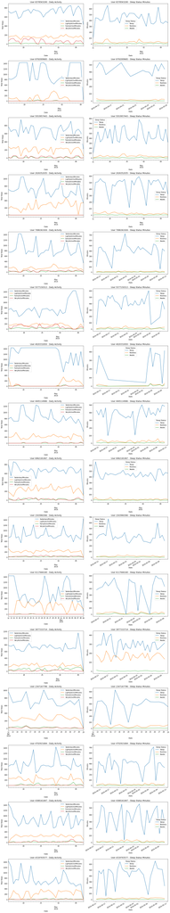

```python
fig, axes = plt.subplots(len(ids), 2, figsize=(15, 5 * len(ids)))

if len(ids) == 1:
    axes = axes[np.newaxis, :]


# Get specific data from each user
for idx, i in enumerate(ids):
    user_activity = daily_activity[daily_activity['Id'] == i]
    user_sleep = sleep_label_counts[sleep_label_counts['Id'] == i]
    # Plot total steps over time
    user_activity.plot(x='ActivityDate', y=['SedentaryMinutes', 'LightlyActiveMinutes', 'FairlyActiveMinutes', 'VeryActiveMinutes'], ax=axes[idx, 0])
    axes[idx, 0].set_title(f'User {i} - Daily Activity')
    axes[idx, 0].set_xlabel('Date')
    axes[idx, 0].set_ylabel('Total Steps')
    axes[idx, 0].legend()

    # Plot sleep status over time
    user_sleep.plot(x='date', y=['Sleep', 'Restless', 'Awake'], ax=axes[idx, 1])
    axes[idx, 1].set_title(f'User {i} - Sleep Status Minutes')
    axes[idx, 1].set_xlabel('Date')
    axes[idx, 1].set_ylabel('Minutes')
    axes[idx, 1].legend(title='Sleep Status')

plt.tight_layout()
plt.show()
```

There is clearly varying data density and fluctuation between users, but an initial visualization shows some promise in correlation.

# Exploritory Data Analysis

Merge all the relevant data into a master dataframe.

```python
# Ensure both date columns are of the same type
daily_activity['ActivityDate'] = pd.to_datetime(daily_activity['ActivityDate'])
sleep_label_counts['date'] = pd.to_datetime(sleep_label_counts['date'])

# Filter IDs
daily_activity = daily_activity[daily_activity['Id'].isin(ids)].copy()
sleep_label_counts = sleep_label_counts[sleep_label_counts['Id'].isin(ids)].copy()

# Merge the grouped data on user ID and date
merged_data = pd.merge(daily_activity, sleep_label_counts, left_on=['Id', 'ActivityDate'], right_on=['Id', 'date'])
merged_data['TotalActiveMinutes'] = merged_data['LightlyActiveMinutes'] + merged_data['FairlyActiveMinutes'] + merged_data['VeryActiveMinutes']
merged_data.drop(columns=['date'], inplace=True)

display(merged_data)
```

|  | Id | ActivityDate | TotalSteps | TotalDistance | TrackerDistance | LoggedActivitiesDistance | VeryActiveDistance | ModeratelyActiveDistance | LightActiveDistance | SedentaryActiveDistance | VeryActiveMinutes | FairlyActiveMinutes | LightlyActiveMinutes | SedentaryMinutes | Calories | Awake | Restless | Sleep | TotalActiveMinutes |
| --- | --- | --- | --- | --- | --- | --- | --- | --- | --- | --- | --- | --- | --- | --- | --- | --- | --- | --- | --- |
| 0 | 1503960366 | 2016-04-12 | 13162 | 8.50 | 8.50 | 0.0 | 1.88 | 0.55 | 6.06 | 0.0 | 25 | 13 | 328 | 728 | 1985 | 6 | 13 | 327 | 366 |
| 1 | 1503960366 | 2016-04-13 | 10735 | 6.97 | 6.97 | 0.0 | 1.57 | 0.69 | 4.71 | 0.0 | 21 | 19 | 217 | 776 | 1797 | 12 | 11 | 384 | 257 |
| 2 | 1503960366 | 2016-04-15 | 9762 | 6.28 | 6.28 | 0.0 | 2.14 | 1.26 | 2.83 | 0.0 | 29 | 34 | 209 | 726 | 1745 | 8 | 22 | 412 | 272 |
| 3 | 1503960366 | 2016-04-16 | 12669 | 8.16 | 8.16 | 0.0 | 2.71 | 0.41 | 5.04 | 0.0 | 36 | 10 | 221 | 773 | 1863 | 8 | 20 | 372 | 267 |
| 4 | 1503960366 | 2016-04-17 | 9705 | 6.48 | 6.48 | 0.0 | 3.19 | 0.78 | 2.51 | 0.0 | 38 | 20 | 164 | 539 | 1728 | 0 | 11 | 668 | 222 |
| ... | ... | ... | ... | ... | ... | ... | ... | ... | ... | ... | ... | ... | ... | ... | ... | ... | ... | ... | ... |
| 402 | 8792009665 | 2016-04-30 | 7174 | 4.59 | 4.59 | 0.0 | 0.33 | 0.36 | 3.91 | 0.0 | 10 | 20 | 301 | 749 | 2896 | 2 | 15 | 343 | 331 |
| 403 | 8792009665 | 2016-05-01 | 1619 | 1.04 | 1.04 | 0.0 | 0.00 | 0.00 | 1.04 | 0.0 | 0 | 0 | 79 | 834 | 1962 | 0 | 24 | 503 | 79 |
| 404 | 8792009665 | 2016-05-02 | 1831 | 1.17 | 1.17 | 0.0 | 0.00 | 0.00 | 1.17 | 0.0 | 0 | 0 | 101 | 916 | 2015 | 0 | 8 | 415 | 101 |
| 405 | 8792009665 | 2016-05-03 | 2421 | 1.55 | 1.55 | 0.0 | 0.00 | 0.00 | 1.55 | 0.0 | 0 | 0 | 156 | 739 | 2297 | 2 | 27 | 516 | 156 |
| 406 | 8792009665 | 2016-05-04 | 2283 | 1.46 | 1.46 | 0.0 | 0.00 | 0.00 | 1.46 | 0.0 | 0 | 0 | 129 | 848 | 2067 | 2 | 22 | 439 | 129 |

407 rows × 19 columns

Build a correlation matrix and heatmap to easily visualize correlation between features.

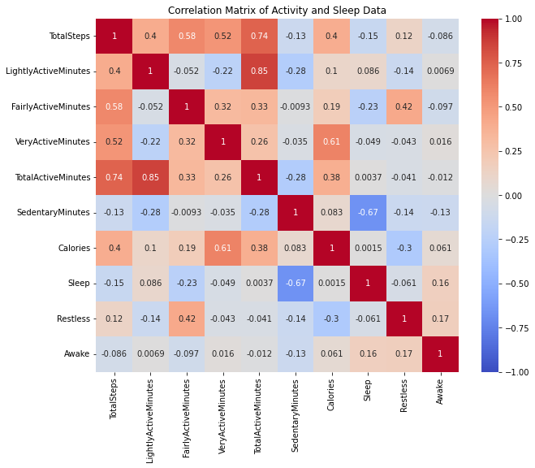

```
Correlation matrix:
```

|  | TotalSteps | LightlyActiveMinutes | FairlyActiveMinutes | VeryActiveMinutes | TotalActiveMinutes | SedentaryMinutes | Calories | Sleep | Restless | Awake |
| --- | --- | --- | --- | --- | --- | --- | --- | --- | --- | --- |
| TotalSteps | 1.000000 | 0.403454 | 0.579302 | 0.521671 | 0.736702 | -0.127255 | 0.397557 | -0.153976 | 0.120915 | -0.085550 |
| LightlyActiveMinutes | 0.403454 | 1.000000 | -0.051737 | -0.222248 | 0.852956 | -0.279315 | 0.104409 | 0.086481 | -0.135760 | 0.006925 |
| FairlyActiveMinutes | 0.579302 | -0.051737 | 1.000000 | 0.319966 | 0.330830 | -0.009338 | 0.186382 | -0.234430 | 0.415839 | -0.096745 |
| VeryActiveMinutes | 0.521671 | -0.222248 | 0.319966 | 1.000000 | 0.261747 | -0.035347 | 0.605311 | -0.048530 | -0.043480 | 0.016396 |
| TotalActiveMinutes | 0.736702 | 0.852956 | 0.330830 | 0.261747 | 1.000000 | -0.282504 | 0.384354 | 0.003705 | -0.040559 | -0.011608 |
| SedentaryMinutes | -0.127255 | -0.279315 | -0.009338 | -0.035347 | -0.282504 | 1.000000 | 0.083266 | -0.666825 | -0.139001 | -0.126558 |
| Calories | 0.397557 | 0.104409 | 0.186382 | 0.605311 | 0.384354 | 0.083266 | 1.000000 | 0.001515 | -0.303861 | 0.060717 |
| Sleep | -0.153976 | 0.086481 | -0.234430 | -0.048530 | 0.003705 | -0.666825 | 0.001515 | 1.000000 | -0.060934 | 0.158576 |
| Restless | 0.120915 | -0.135760 | 0.415839 | -0.043480 | -0.040559 | -0.139001 | -0.303861 | -0.060934 | 1.000000 | 0.171612 |
| Awake | -0.085550 | 0.006925 | -0.096745 | 0.016396 | -0.011608 | -0.126558 | 0.060717 | 0.158576 | 0.171612 | 1.000000 |

```python
correlation_matrix = merged_data[['TotalSteps', 'LightlyActiveMinutes', 'FairlyActiveMinutes', 'VeryActiveMinutes', 'TotalActiveMinutes', 'SedentaryMinutes', 'Calories', 'Sleep', 'Restless', 'Awake']].corr()

plt.figure(figsize=(10, 8))
sns.heatmap(correlation_matrix, annot=True, cmap='coolwarm', vmin=-1, vmax=1)
plt.title('Correlation Matrix of Activity and Sleep Data')
plt.show()

print("Correlation matrix:")
display(correlation_matrix)
```

Many features, such as active minutes and total steps have high correlation as expected. However, contrary to our hypothesis, total activity and sleep do not seem to have very strong correlation. However, sedentary minutes, which is the direct opposite of activity, seems to have a negative correlation with sleep, which supports out hypothesis.

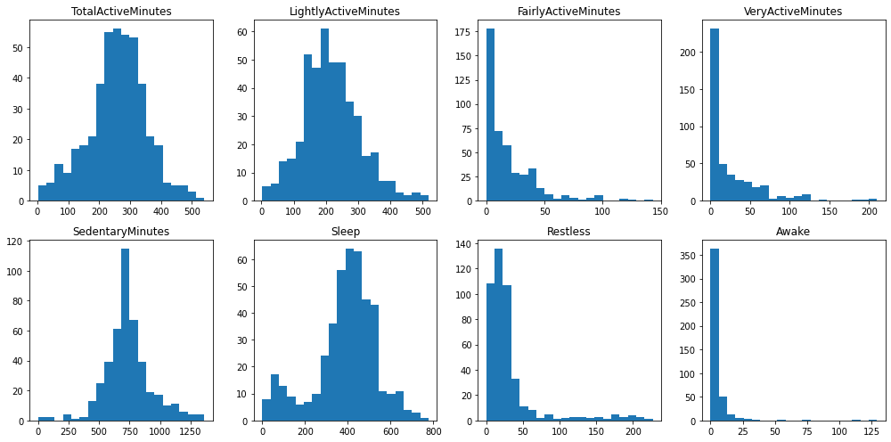

```python
# Plot histograms for each metric
metrics = ['TotalActiveMinutes','LightlyActiveMinutes', 'FairlyActiveMinutes', 'VeryActiveMinutes', 'SedentaryMinutes','Sleep', 'Restless', 'Awake']
plt.figure(figsize=(14, 7))
for i, metric in enumerate(metrics):
    plt.subplot(2, 4, i+1)
    plt.hist(merged_data[metric], bins=20)
    plt.title(metric)
plt.tight_layout()
plt.show()
```

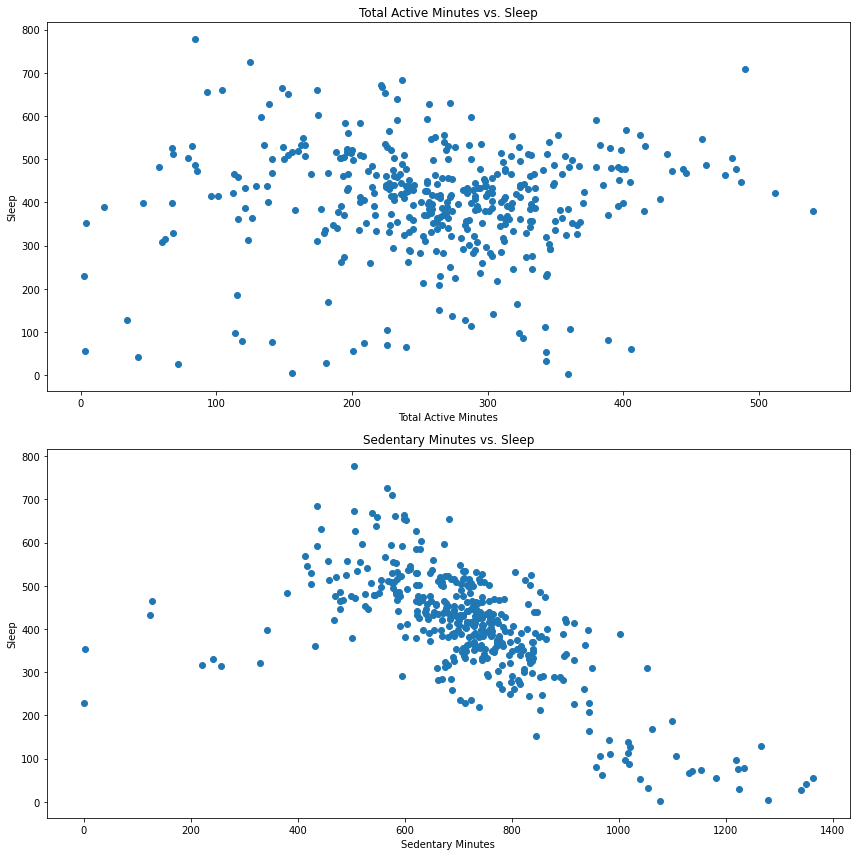

```python
# Scatter plots for activity vs. sleep patterns
plt.figure(figsize=(12, 12))
plt.subplot(2, 1, 1)
plt.scatter(merged_data['TotalActiveMinutes'], merged_data['Sleep'])
plt.title('Total Active Minutes vs. Sleep')
plt.xlabel('Total Active Minutes')
plt.ylabel('Sleep')

plt.subplot(2, 1, 2)
plt.scatter(merged_data['SedentaryMinutes'], merged_data['Sleep'])
plt.title('Sedentary Minutes vs. Sleep')
plt.xlabel('Sedentary Minutes')
plt.ylabel('Sleep')

plt.tight_layout()
plt.show()
```

There does not seem to be a strong relationship between activity time and sleep time. Let's explore sedentary time instead.

```
Coefficients: [-0.54435443], Intercept: 791.4778756606722
Mean Squared Error (MSE): 10295.298872315905
R-squared: 0.5127657382918016
Adjusted R-squared: 0.5116558652582976
```

[figure not shown]

```python
X = merged_data[['SedentaryMinutes']]
y = merged_data['Sleep']

# Fit linear regression model
model = LinearRegression()
model.fit(X, y)

# Predict sleep duration
predicted_sleep = model.predict(X)

# Calculate Mean Squared Error (MSE)
mse = mean_squared_error(y, predicted_sleep)

# Calculate R-squared and Adjusted R-squared
r2 = r2_score(y, predicted_sleep)
n = len(y)
p = X.shape[1]
adjusted_r2 = 1 - (1 - r2) * (n - 1) / (n - p - 1)

# Display the regression line and calculated values
print(f"Coefficients: {model.coef_}, Intercept: {model.intercept_}")
print(f"Mean Squared Error (MSE): {mse}")
print(f"R-squared: {r2}")
print(f"Adjusted R-squared: {adjusted_r2}")

# Plot the regression line for one of the features (e.g., TotalSteps vs. Sleep)
plt.figure(figsize=(14, 7))
plt.scatter(X, y, label='Actual Data')
plt.plot(X['SedentaryMinutes'], predicted_sleep, color='red', linewidth=2, label='Regression Line')
plt.xlabel('Sedentary Minutes')
plt.ylabel('Sleep Duration')
plt.title('Total Steps vs. Sleep Duration with Regression Line')
plt.legend()
plt.show()
```

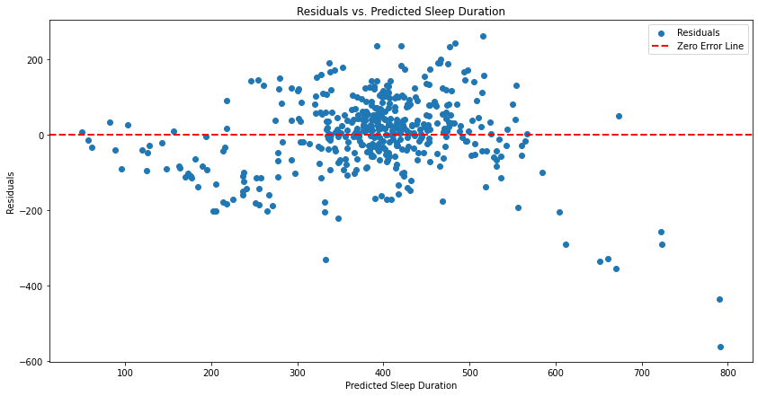

```python
predicted_sleep = model.predict(X)

# Calculate residuals
residuals = y - predicted_sleep

# Plot residuals
plt.figure(figsize=(14, 7))
plt.scatter(predicted_sleep, residuals, label='Residuals')
plt.axhline(y=0, color='red', linestyle='--', linewidth=2, label='Zero Error Line')
plt.xlabel('Predicted Sleep Duration')
plt.ylabel('Residuals')
plt.title('Residuals vs. Predicted Sleep Duration')
plt.legend()
plt.show()
```

There is a pattern in the residuals, suggesting the linear model may not be the best candidate. Furthermore, the linear regression suggests 0 sedentary minutes could result in over 13 hours of sleep, which is highly unrealistic. Let's try a polynomial model instead to capture the flatter tails that seem to appear at the ends of the data.

```
Regression Coefficients: [ 0.00000000e+00  8.28076688e-01  6.06597090e-05 -2.15389013e-06
  1.16049503e-09], Intercept: 290.7668650538366
Polynomial Model MSE: 7152.185338229747
Polynomial Model Adjusted R-squared: 0.657625792013997
```

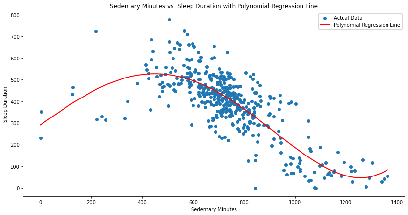

```python
# Prepare data for polynomial regression
poly = PolynomialFeatures(degree=4)
X_poly = poly.fit_transform(X)

# Fit polynomial regression model
poly_model = LinearRegression()
poly_model.fit(X_poly, y)

# Predict sleep duration using the polynomial model
predicted_sleep_poly = poly_model.predict(X_poly)

# Calculate MSE for the polynomial model
mse_poly = mean_squared_error(y, predicted_sleep_poly)

# Calculate adjusted R-squared for the polynomial model
r2_poly = r2_score(y, predicted_sleep_poly)
n = len(y)
p_poly = X_poly.shape[1]
adjusted_r2_poly = 1 - (1 - r2_poly) * (n - 1) / (n - p_poly - 1)

print(f"Regression Coefficients: {poly_model.coef_}, Intercept: {poly_model.intercept_}")
print(f"Polynomial Model MSE: {mse_poly}")
print(f"Polynomial Model Adjusted R-squared: {adjusted_r2_poly}")

# Plot the polynomial regression line for TotalSteps vs Sleep
# Sort the data by TotalSteps for plotting purposes
sorted_indices = np.argsort(X['SedentaryMinutes'])
X_sorted = X.iloc[sorted_indices]
y_sorted = y.iloc[sorted_indices]
predicted_sleep_poly_sorted = predicted_sleep_poly[sorted_indices]

plt.figure(figsize=(14, 7))
plt.scatter(X_sorted['SedentaryMinutes'], y_sorted, label='Actual Data')
plt.plot(X_sorted['SedentaryMinutes'], predicted_sleep_poly_sorted, color='red', linewidth=2, label='Polynomial Regression Line')
plt.xlabel('Sedentary Minutes')
plt.ylabel('Sleep Duration')
plt.title('Sedentary Minutes vs. Sleep Duration with Polynomial Regression Line')
plt.legend()
plt.show()
```

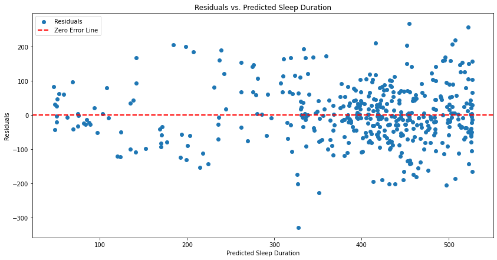

```python
predicted_sleep = poly_model.predict(X_poly)

# Calculate residuals
residuals = y - predicted_sleep

# Plot residuals
plt.figure(figsize=(14, 7))
plt.scatter(predicted_sleep, residuals, label='Residuals')
plt.axhline(y=0, color='red', linestyle='--', linewidth=2, label='Zero Error Line')
plt.xlabel('Predicted Sleep Duration')
plt.ylabel('Residuals')
plt.title('Residuals vs. Predicted Sleep Duration')
plt.legend()
plt.show()
```

This model appears to fit much better, indicted by the lower MSE, higher R-squared, and more random residual plot.

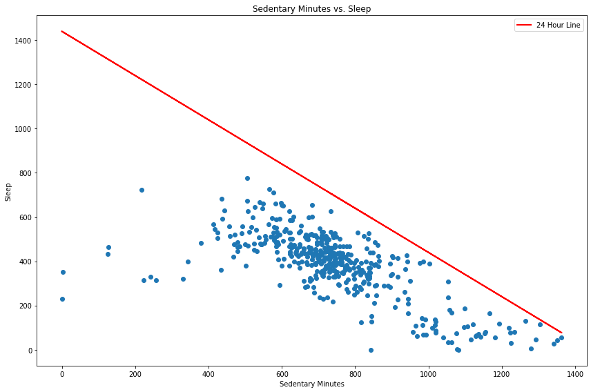

```python
plt.figure(figsize=(12, 8))
plt.scatter(merged_data['SedentaryMinutes'], merged_data['Sleep'])
plt.plot(merged_data['SedentaryMinutes'], 24*60-merged_data['SedentaryMinutes'], color='red', linewidth=2, label='24 Hour Line')
plt.title('Sedentary Minutes vs. Sleep')
plt.xlabel('Sedentary Minutes')
plt.ylabel('Sleep')
plt.legend()

plt.tight_layout()
plt.show()
```

However, it is important to note that sedetary minutes and sleep time take up most of the 24-hour day, and their correlation seems to be related to the fact that they are dependant in this way.

Let's try a machine learning model to try and uncover less obvious trends in the data. Random Forest can effectively handle a mix of numerical features, such as activity metrics and sedentary minutes, and it is less sensitive to multicollinearity among the features compared to linear models. Finally, we can use it to determine feature importance.

```python
# Include all relevant activity metrics and sedentary minutes as features
features = ['TotalSteps', 'LightlyActiveMinutes', 'FairlyActiveMinutes', 'VeryActiveMinutes', 'SedentaryMinutes']
X = merged_data[features]
y = merged_data['Sleep']

# Split the data into training and testing sets
X_train, X_test, y_train, y_test = train_test_split(X, y, test_size=0.2, random_state=0)

# Train a Random Forest model
rf_model = RandomForestRegressor(n_estimators=100, random_state=42)
rf_model.fit(X_train, y_train)

# Predict sleep duration on the test set
y_pred = rf_model.predict(X_test)

# Evaluate the model
mse = mean_squared_error(y_test, y_pred)
r2 = r2_score(y_test, y_pred)
n = len(y_test)
p = X_test.shape[1]
adjusted_r2 = 1 - (1 - r2) * (n - 1) / (n - p - 1)

print(f"Random Forest Model MSE: {mse}")
print(f"Random Forest Model R-squared: {r2}")
print(f"Random Forest Model Adjusted R-squared: {adjusted_r2}")
```

```
Random Forest Model MSE: 2793.333360674157
Random Forest Model R-squared: 0.8362467335565578
Random Forest Model Adjusted R-squared: 0.8263820789515312
```

```
                      Importance
SedentaryMinutes        0.748808
TotalSteps              0.120876
LightlyActiveMinutes    0.086169
FairlyActiveMinutes     0.031852
VeryActiveMinutes       0.012295
```

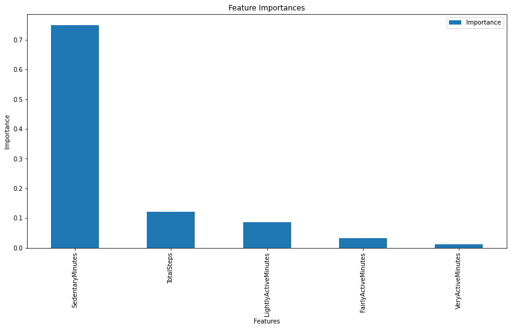

```python
# Get feature importances
feature_importances = pd.DataFrame(rf_model.feature_importances_, index=features, columns=['Importance']).sort_values('Importance', ascending=False)
print(feature_importances)

# Plot feature importances
import matplotlib.pyplot as plt
feature_importances.plot(kind='bar', figsize=(14, 7))
plt.title('Feature Importances')
plt.xlabel('Features')
plt.ylabel('Importance')
plt.show()
```

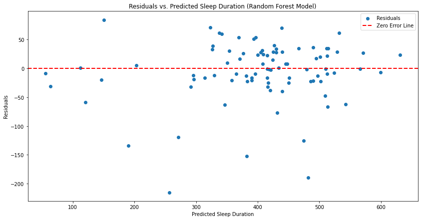

```python
# Calculate residuals
residuals = y_test - y_pred

# Plot residuals
plt.figure(figsize=(14, 7))
plt.scatter(y_pred, residuals, label='Residuals')
plt.axhline(y=0, color='red', linestyle='--', linewidth=2, label='Zero Error Line')
plt.xlabel('Predicted Sleep Duration')
plt.ylabel('Residuals')
plt.title('Residuals vs. Predicted Sleep Duration (Random Forest Model)')
plt.legend()
plt.show()
```

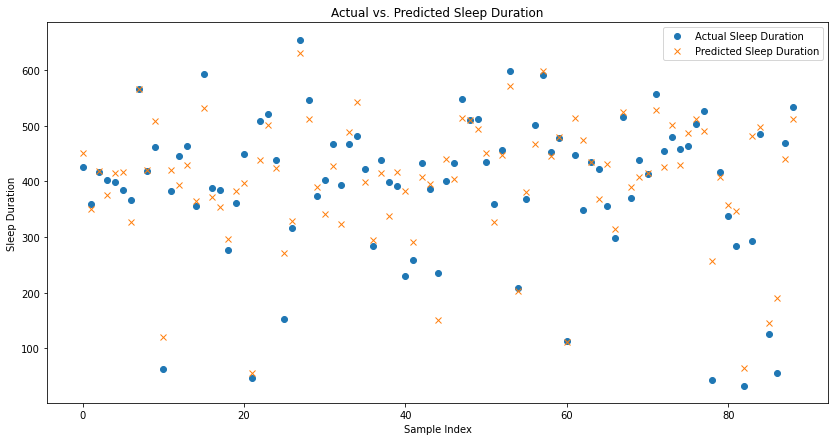

```python
# Ensure that y_test and y_pred have the same index for proper plotting
y_test = y_test.reset_index(drop=True)
y_pred = pd.Series(y_pred)

# Plot the predictions and actual data
plt.figure(figsize=(14, 7))
plt.plot(y_test, label='Actual Sleep Duration', marker='o', linestyle='none')
plt.plot(y_pred, label='Predicted Sleep Duration', marker='x', linestyle='none')
plt.xlabel('Sample Index')
plt.ylabel('Sleep Duration')
plt.title('Actual vs. Predicted Sleep Duration')
plt.legend()
plt.show()
```

# Conclusion

While I was able to find a relationship between sedentary time and sleep time, it may not be extremely strong. Overall, research suggests the timing, intensity, and type of exercise play crucial roles in determining its effects on sleep. For example, moderate aerobic exercise is typically associated with improved sleep, whereas high-intensity exercise close to bedtime may disrupt sleep patterns. The complexity of this relationship necessitates further investigation to understand individual variations and optimize exercise recommendations for sleep health. There are also several [other factors on sleep](https://www.mayoclinic.org/healthy-lifestyle/adult-health/in-depth/sleep/art-20048379) that may play a larger role in determining sleep duration. In the future, I hope to gather measures of specific sleep quality and other lifestyle features that could affect sleep.